# InSPIRe Vaginal Resistome R Notebook (3): Statistical analysis

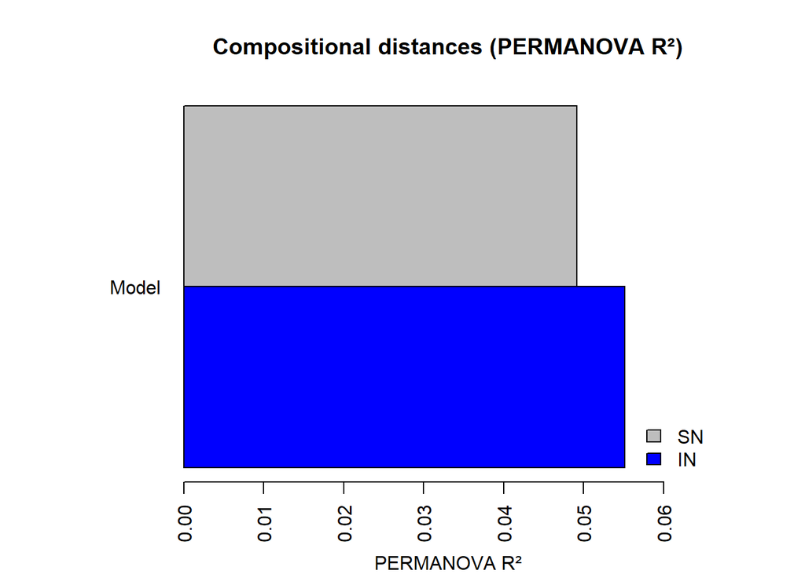

```r
plot_adonis_R2(
  adonis_ARGs_IN,
  adonis_ARGs_SN,
  title = "Compositional distances (PERMANOVA R²)"
)
```

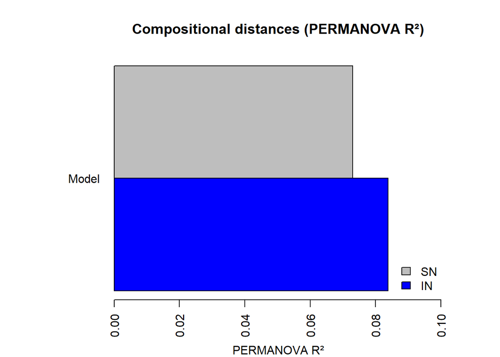

```r
plot_adonis_R2(
  adonis_MGEs_IN,
  adonis_MGEs_SN,
  title = "Compositional distances (PERMANOVA R²)"
)
```

```r
# Clinical outcome model
formula_CG <- ~ OUT_GROUP + BIL_INC_ATB + PAT_AGE + IMC + CERCLAGE + RCIU + DIABET_GESTA + HTA_PRE_ECLAM

# IN samples
x <- align_meta_mat(Taxo_IN, metadata_IN)
adonis_taxo_CG_IN_m <- adonis_analysis(x$mat, x$meta, formula_CG, "bray", by = "margin")
x <- align_meta_mat(ARGs_IN, metadata_IN)
adonis_args_CG_IN_m <- adonis_analysis(x$mat, x$meta, formula_CG, "jaccard", by = "margin")
x <- align_meta_mat(MGEs_IN, metadata_IN)
adonis_mges_CG_IN_m <- adonis_analysis(x$mat, x$meta, formula_CG, "jaccard", by = "margin")

# DR samples
x <- align_meta_mat(Taxo_SN, metadata_SN)
adonis_taxo_CG_SN_m <- adonis_analysis(x$mat, x$meta, formula_CG, "bray", by = "margin")
x <- align_meta_mat(ARGs_SN, metadata_SN)
adonis_args_CG_SN_m <- adonis_analysis(x$mat, x$meta, formula_CG, "jaccard", by = "margin")
x <- align_meta_mat(MGEs_SN, metadata_SN)
adonis_mges_CG_SN_m <- adonis_analysis(x$mat, x$meta, formula_CG, "jaccard", by = "margin")
```

```r
print(adonis_taxo_CG_IN_m); print(adonis_taxo_CG_SN_m)
```

```
## Permutation test for adonis under reduced model
## Marginal effects of terms
## Permutation: free
## Number of permutations: 999
##
## adonis2(formula = dist ~ ., data = model.frame(formula, metadata), permutations = permutations, by = by)
##                 Df SumOfSqs      R2      F Pr(>F)
## OUT_GROUP        3     3.27 0.00802 2.8091  0.001 ***
## BIL_INC_ATB      1     1.19 0.00290 3.0519  0.005 **
## PAT_AGE          1     0.70 0.00173 1.8139  0.055 .
## IMC              1     2.63 0.00644 6.7628  0.001 ***
## CERCLAGE         1     0.72 0.00178 1.8661  0.038 *
## RCIU             1     0.42 0.00103 1.0831  0.306
## DIABET_GESTA     1     0.31 0.00075 0.7927  0.637
## HTA_PRE_ECLAM    1     0.33 0.00081 0.8515  0.556
## Residual      1022   397.02 0.97264
## Total         1032   408.19 1.00000
## ---
## Signif. codes:  0 '***' 0.001 '**' 0.01 '*' 0.05 '.' 0.1 ' ' 1
```

```
## Permutation test for adonis under reduced model
## Marginal effects of terms
## Permutation: free
## Number of permutations: 999
##
## adonis2(formula = dist ~ ., data = model.frame(formula, metadata), permutations = permutations, by = by)
##                Df SumOfSqs      R2      F Pr(>F)
## OUT_GROUP       3     4.28 0.01135 3.4976  0.001 ***
## BIL_INC_ATB     1     0.45 0.00118 1.0915  0.309
## PAT_AGE         1     0.64 0.00169 1.5588  0.090 .
## IMC             1     2.57 0.00681 6.3003  0.001 ***
## CERCLAGE        1     0.75 0.00200 1.8502  0.042 *
## RCIU            1     0.29 0.00076 0.7032  0.768
## DIABET_GESTA    1     0.30 0.00080 0.7386  0.716
## HTA_PRE_ECLAM   1     0.36 0.00095 0.8769  0.592
## Residual      899   366.68 0.97225
## Total         909   377.14 1.00000
## ---
## Signif. codes:  0 '***' 0.001 '**' 0.01 '*' 0.05 '.' 0.1 ' ' 1
```

```r
print(adonis_args_CG_IN_m); print(adonis_args_CG_SN_m)
```

```
## Permutation test for adonis under reduced model
## Marginal effects of terms
## Permutation: free
## Number of permutations: 999
##
## adonis2(formula = dist ~ ., data = model.frame(formula, metadata), permutations = permutations, by = by)
##                Df SumOfSqs      R2      F Pr(>F)
## OUT_GROUP       3    1.510 0.00692 1.4096  0.065 .
## BIL_INC_ATB     1    0.439 0.00201 1.2280  0.226
## PAT_AGE         1    0.416 0.00191 1.1646  0.266
## IMC             1    1.007 0.00462 2.8210  0.010 **
## CERCLAGE        1    0.339 0.00155 0.9490  0.426
## RCIU            1    0.359 0.00165 1.0056  0.376
## DIABET_GESTA    1    0.458 0.00210 1.2827  0.203
## HTA_PRE_ECLAM   1    0.418 0.00192 1.1711  0.263
## Residual      596  212.834 0.97504
## Total         606  218.282 1.00000
## ---
## Signif. codes:  0 '***' 0.001 '**' 0.01 '*' 0.05 '.' 0.1 ' ' 1
```

```
## Permutation test for adonis under reduced model
## Marginal effects of terms
## Permutation: free
## Number of permutations: 999
##
## adonis2(formula = dist ~ ., data = model.frame(formula, metadata), permutations = permutations, by = by)
##                Df SumOfSqs      R2      F Pr(>F)
## OUT_GROUP       3    1.720 0.00975 1.5758  0.023 *
## BIL_INC_ATB     1    0.528 0.00299 1.4516  0.127
## PAT_AGE         1    0.731 0.00414 2.0080  0.025 *
## IMC             1    0.313 0.00178 0.8615  0.545
## CERCLAGE        1    0.570 0.00323 1.5670  0.099 .
## RCIU            1    0.510 0.00289 1.4015  0.146
## DIABET_GESTA    1    0.228 0.00130 0.6279  0.859
## HTA_PRE_ECLAM   1    0.273 0.00155 0.7501  0.666
## Residual      470  171.031 0.96968
## Total         480  176.378 1.00000
## ---
## Signif. codes:  0 '***' 0.001 '**' 0.01 '*' 0.05 '.' 0.1 ' ' 1
```

```r
print(adonis_mges_CG_IN_m); print(adonis_mges_CG_SN_m)
```

```
## Permutation test for adonis under reduced model
## Marginal effects of terms
## Permutation: free
## Number of permutations: 999
##
## adonis2(formula = dist ~ ., data = model.frame(formula, metadata), permutations = permutations, by = by)
##                Df SumOfSqs      R2      F Pr(>F)
## OUT_GROUP       3    2.032 0.00941 1.9660  0.010 **
## BIL_INC_ATB     1    0.400 0.00185 1.1613  0.268
## PAT_AGE         1    1.197 0.00554 3.4755  0.004 **
## IMC             1    0.840 0.00389 2.4374  0.028 *
## CERCLAGE        1    0.597 0.00276 1.7337  0.073 .
## RCIU            1    0.248 0.00115 0.7192  0.671
## DIABET_GESTA    1    0.357 0.00165 1.0359  0.348
## HTA_PRE_ECLAM   1    0.489 0.00226 1.4190  0.146
## Residual      607  209.131 0.96802
## Total         617  216.040 1.00000
## ---
## Signif. codes:  0 '***' 0.001 '**' 0.01 '*' 0.05 '.' 0.1 ' ' 1
```

```
## Permutation test for adonis under reduced model
## Marginal effects of terms
## Permutation: free
## Number of permutations: 999
##
## adonis2(formula = dist ~ ., data = model.frame(formula, metadata), permutations = permutations, by = by)
##                Df SumOfSqs      R2      F Pr(>F)
## OUT_GROUP       3    2.703 0.01516 2.5835  0.002 **
## BIL_INC_ATB     1    0.423 0.00237 1.2118  0.223
## PAT_AGE         1    0.274 0.00154 0.7854  0.563
## IMC             1    0.548 0.00308 1.5727  0.104
## CERCLAGE        1    0.188 0.00105 0.5380  0.920
## RCIU            1    0.384 0.00216 1.1023  0.277
## DIABET_GESTA    1    0.311 0.00175 0.8931  0.452
## HTA_PRE_ECLAM   1    0.282 0.00158 0.8075  0.575
## Residual      494  172.291 0.96632
## Total         504  178.295 1.00000
## ---
## Signif. codes:  0 '***' 0.001 '**' 0.01 '*' 0.05 '.' 0.1 ' ' 1
```

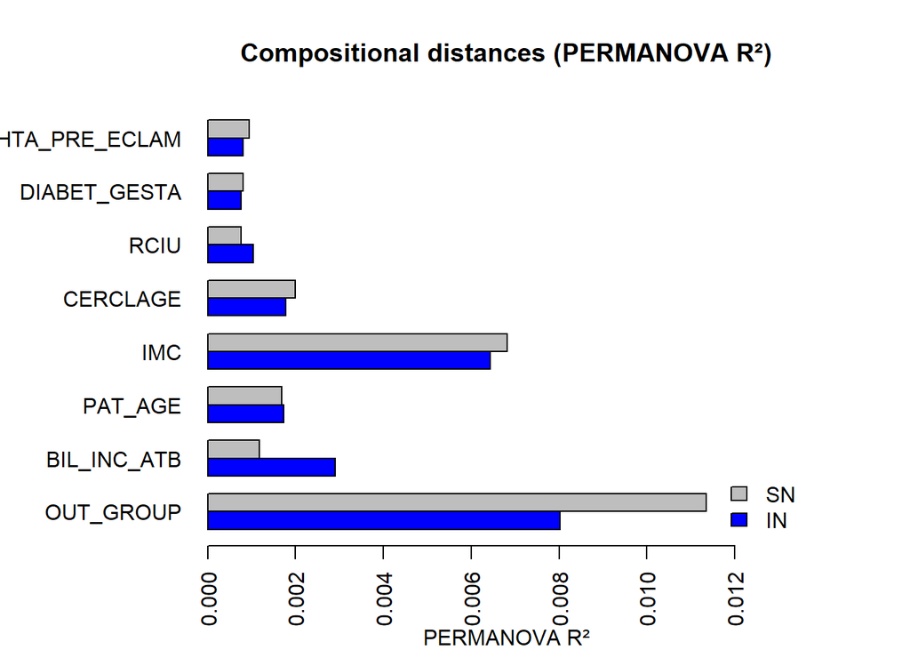

```r
plot_adonis_R2(
  adonis_taxo_CG_IN_m,
  adonis_taxo_CG_SN_m,
  title = "Compositional distances (PERMANOVA R²)"
)
```

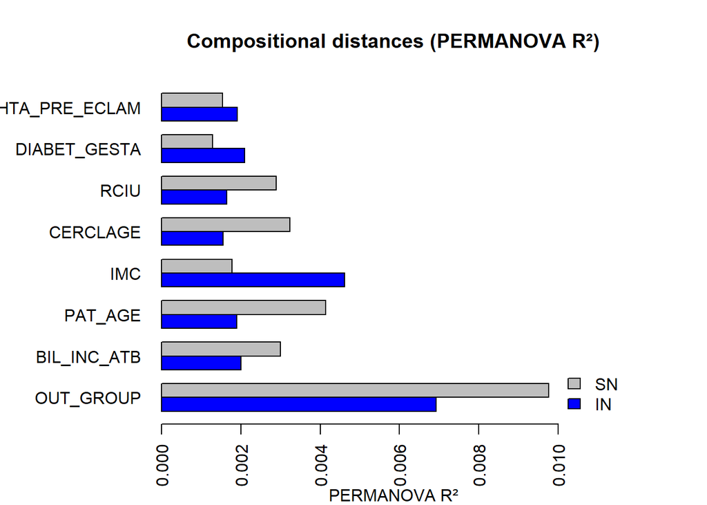

```r
plot_adonis_R2(
  adonis_args_CG_IN_m,
  adonis_args_CG_SN_m,
  title = "Compositional distances (PERMANOVA R²)"
)
```

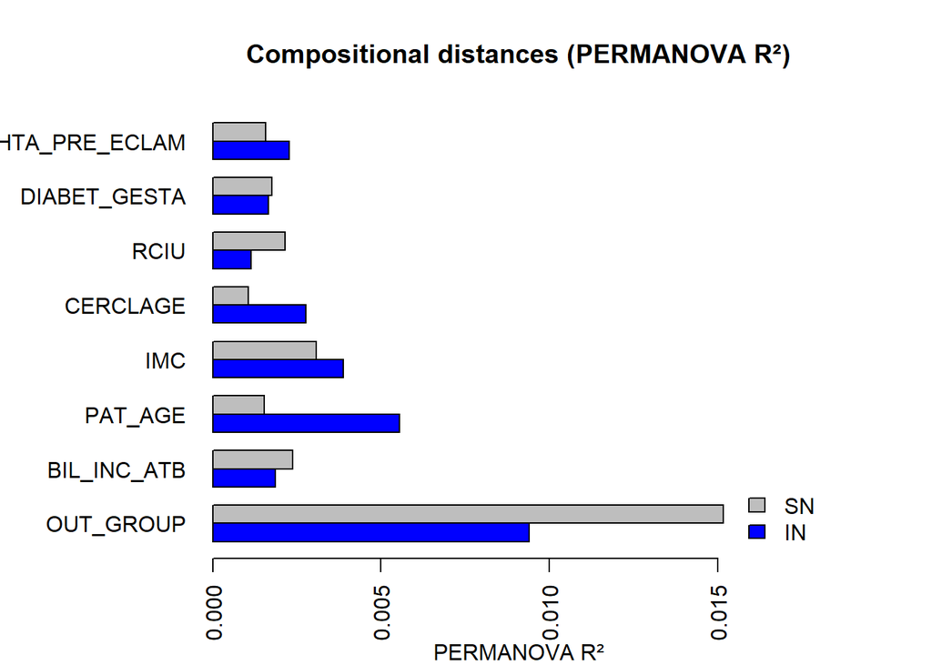

```r
plot_adonis_R2(
  adonis_mges_CG_IN_m,
  adonis_mges_CG_SN_m,
  title = "Compositional distances (PERMANOVA R²)"
)
```

# (3) Differential abundance analysis (using MaAslin2)

To evaluate features differential abundance, we applied two different models to account for the structure of the dat:

**LM_CLR**: CLR-transformed linear model, used for microbial species. **CPLM**: used for ARGs and MGEs, which are rarer

```r
# Build a function to run MaAsLin2 using the two different models described above and extract a standard output for visualisation.
maaslin_go <- function(count_data, metadata, variables, ref_levels, random_effects = NULL,
                       method = c("LM_CLR", "CPLM"), output_dir = "maaslin_output") {
  method <- match.arg(method)

  params <- switch(method,
                   LM_CLR = list(norm = "CLR", trans = "NONE", ana = "LM"), #model for species
                   CPLM   = list(norm = "CLR", trans = "LOG",  ana = "CPLM") #model for ARGs and MGEs
  )

  Maaslin2(
    input_data = count_data,
    input_metadata  = metadata,
    output = output_dir,
    fixed_effects = variables,
    random_effects = random_effects,
    normalization = params$norm,transform = params$trans,
    analysis_method = params$ana,
    reference = paste(names(ref_levels), ref_levels, sep = ","),
    min_prevalence = 0, max_significance = 1,
    plot_heatmap = FALSE, plot_scatter = FALSE
  )
# Extract and format ouput table
  res_file <- file.path(output_dir, "all_results.tsv")
  read.delim(res_file) |>
    dplyr::filter(metadata %in% variables) |>
    dplyr::transmute(
      feature,
      variable  = metadata,
      level     = trimws(value),
      estimate  = coef, std.error = stderr, p.value = pval, q.value = qval,
      method    = method
    )
}
# Filter features
custom_filter <- function(df, prev_cutoff = NULL, abund_cutoff = NULL) {
  prevalence <- colSums(df > 0) / nrow(df)
  abundance  <- colMeans(df, na.rm = TRUE)
  keep <- prevalence >= prev_cutoff & abundance >= abund_cutoff
  df_filtered <- df[, keep, drop = FALSE]
  return(df_filtered)
}
```

```r
#by prevalence
prev_cutoff_sp   <- 0.4
prev_cutoff_argmge <- 0 # As ARGs and MGEs are rarer
# by min abundance
abund_cutoff  <- 50 # for all features

Taxonomy_count_filtered <- custom_filter(Taxo_count,prev_cutoff_sp, abund_cutoff)
ARGs_count_filtered <- custom_filter(ARGs_count, prev_cutoff_argmge, abund_cutoff)
ARGs_count_class_filtered <- custom_filter(ARGs_count_class, prev_cutoff_argmge, abund_cutoff)
MGEs_count_filtered <- custom_filter(MGEs_count, prev_cutoff_argmge, abund_cutoff)
MGEs_count_family_filtered <- custom_filter(MGEs_count_family, prev_cutoff_argmge, abund_cutoff)

metadata <- metadata %>% column_to_rownames("SampleID")
```

## MaAslin2 for Community State Type (CST)

```r
runs <- list(
  Taxa      = list(data = Taxonomy_count_filtered,method = "LM_CLR", out = "maaslin2_Taxa_LMCLR_CST"),
  ARGs      = list(data = ARGs_count_filtered,method = "CPLM", out = "maaslin2_ARGs_CPLM_CST"),
  ARGsClass = list(data = ARGs_count_class_filtered,method = "CPLM", out = "maaslin2_ARGsClass_CPLM_CST"),
  MGEs      = list(data = MGEs_count_filtered,method = "CPLM", out = "maaslin2_MGEs_CPLM_CST"),
  MGEsfanily = list(data = MGEs_count_family_filtered,method = "CPLM", out = "maaslin2_MGEsfamily_CPLM_CST")
)

res <- lapply(runs, \(x)
  maaslin_go(
    count_data= x$data,
    metadata= metadata,
    variables= "CST",
    ref_levels= c(CST = "CST I"),
    random_effects = "PATIENT",
    method= x$method,
    output_dir= x$out
  )
)

Taxa_res_lmclr_CST <- res$Taxa
ARGs_res_CPLM_CST <- res$ARGs
ARGs_res_CPLM_ATBClass_CST  <- res$ARGsClass
MGEs_res_CPLM_CST <- res$MGEs
MGEsfamily_res_CPLM_CST <- res$MGEsfanily
```

## MaAslin2 for Clinical groups (A-D)

```r
vars <- c("OUT_GROUP","BIL_INC_ATB","PAT_AGE","IMC","CERCLAGE","RCIU","DIABET_GESTA","HTA_PRE_ECLAM")

refs <- c(
  OUT_GROUP = "A", BIL_INC_ATB = "No", DIABET_GESTA = "No", CERCLAGE = "No", RCIU = "No", HTA_PRE_ECLAM = "No"
)

runs <- list(
  Taxa = list(data = Taxonomy_count_filtered, method = "LM_CLR", out = "maaslin2_Taxa_LMCLR_ATB"),
  ARGs = list(data = ARGs_count_filtered, method = "CPLM",   out = "maaslin2_ARGs_CPLM_ATB"),
  ARGsClass = list(data = ARGs_count_class_filtered,method = "CPLM",   out = "maaslin2_ARGsClass_CPLM_ATB"),
  MGEs = list(data = MGEs_count_filtered, method = "CPLM", out = "maaslin2_MGEs_CPLM_ATB"),
  MGEsFamily = list(data = MGEs_count_family_filtered, method = "CPLM", out = "maaslin2_MGEsFamily_CPLM_ATB")
)

res <- lapply(runs, \(x)
  maaslin_go( count_data = x$data, metadata = metadata,
              variables = vars,ref_levels = refs, random_effects = "PATIENT",
              method = x$method, output_dir     = x$out
  )
)

Taxa_res_lmclr        <- res$Taxa
ARGs_res_CPLM         <- res$ARGs
ARGsClass_res_CPLM    <- res$ARGsClass
MGEs_res_CPLM   <- res$MGEs
MGEsfamily_res_CPLM   <- res$MGEsFamily
```

## Cross validation using an external and independent cohort study

**Study information** :

Feehily, C., Crosby, D., Walsh, C.J. et al. Shotgun sequencing of the vaginal microbiome reveals both a species and functional potential signature of preterm birth. #npj Biofilms Microbiomes 6, 50 (2020). https://doi.org/10.1038/s41522-020-00162-8

Raw Sequence data have been deposited in the European Nucleotide Archive (ENA) under the study accession number PRJEB34536.

```r
# confirm that CST is a major determinant linked to CST
metadata_ED_df <- as.data.frame(metadata_ED)
rownames(metadata_ED_df) <- metadata_ED_df$SampleID
cst_levels <- c("CST I", "CST II", "CST III", "CST IV", "CST V")

## ARGs: Shannon
df_arg_shannon <- format_adiv(ED_ARGs_adiv, metadata_df = metadata_ED_df, "ED_Shannon")
res_arg_shannon <- compute_univ(df_arg_shannon, patient_col  = "SampleID", "ED_Shannon", "CST", cst_levels)
```

```
##
##                            Comparison of x by group
##                              (Benjamini-Hochberg)
## Col Mean-|
## Row Mean |      CST I     CST II    CST III     CST IV
## ---------+--------------------------------------------
##   CST II |  -1.023780
##          |     0.2185
##  CST III |  -3.664282  -2.361704
##          |    0.0012*     0.0455
##   CST IV |  -2.134246  -1.265754   0.591307
##          |     0.0547     0.2056     0.3080
##    CST V |  -0.752646   0.094102   2.104883   1.218870
##          |     0.2823     0.4625     0.0441     0.1857
##
##
## List of pairwise comparisons: Z statistic (adjusted p-value)
## --------------------------------------
## CST I - CST II   : -1.023780 (0.2185)
## CST I - CST III  : -3.664282 (0.0012)*
## CST II - CST III : -2.361704 (0.0455)
## CST I - CST IV   : -2.134246 (0.0547)
## CST II - CST IV  : -1.265754 (0.2056)
## CST III - CST IV :  0.591307 (0.3080)
## CST I - CST V    : -0.752646 (0.2823)
## CST II - CST V   :  0.094102 (0.4625)
## CST III - CST V  :  2.104883 (0.0441)
## CST IV - CST V   :  1.218870 (0.1857)
##
## alpha = 0.05
## Reject Ho if p <= alpha/2
```

```r
res_arg_shannon$kruskal
```

```
##
##  Kruskal-Wallis rank sum test
##
## data:  ED_Shannon by CST
## Kruskal-Wallis chi-squared = 15.366, df = 4, p-value = 0.003998
```

```r
res_arg_shannon$wilcox
```

```r
res_arg_shannon$summary
```

```r
## ARGs: PRDI
df_arg_prdi <- format_adiv(ED_ARGs_adiv, metadata_ED_df, "ED_PD")
res_arg_prdi <- compute_univ(df_arg_prdi, patient_col  = "SampleID", "ED_PD", "CST", cst_levels)
```

```
##
##                            Comparison of x by group
##                              (Benjamini-Hochberg)
## Col Mean-|
## Row Mean |      CST I     CST II    CST III     CST IV
## ---------+--------------------------------------------
##   CST II |  -1.004966
##          |     0.2249
##  CST III |  -5.315786  -3.873798
##          |    0.0000*    0.0002*
##   CST IV |  -4.086056  -3.119944  -0.090240
##          |    0.0001*    0.0015*     0.4640
##    CST V |  -0.439463   0.372161   3.674261   3.122567
##          |     0.4127     0.3943    0.0003*    0.0018*
##
##
## List of pairwise comparisons: Z statistic (adjusted p-value)
## --------------------------------------
## CST I - CST II   : -1.004966 (0.2249)
## CST I - CST III  : -5.315786 (0.0000)*
## CST II - CST III : -3.873798 (0.0002)*
## CST I - CST IV   : -4.086056 (0.0001)*
## CST II - CST IV  : -3.119944 (0.0015)*
## CST III - CST IV : -0.090240 (0.4640)
## CST I - CST V    : -0.439463 (0.4127)
## CST II - CST V   :  0.372161 (0.3943)
## CST III - CST V  :  3.674261 (0.0003)*
## CST IV - CST V   :  3.122567 (0.0018)*
##
## alpha = 0.05
## Reject Ho if p <= alpha/2
```

```r
res_arg_prdi$kruskal
```

```
##
##  Kruskal-Wallis rank sum test
##
## data:  ED_PD by CST
## Kruskal-Wallis chi-squared = 40.536, df = 4, p-value = 3.352e-08
```

```r
res_arg_prdi$wilcox
```

```r
res_arg_prdi$summary
```

```r
# Regroup CST: I+II+V vs III+IV
metadata_ED_df$CST_grp <- ifelse(metadata_ED_df$CST %in% c("CST I", "CST II", "CST V"),
                                "CST I/II/V",
                                ifelse(metadata_ED_df$CST %in% c("CST III", "CST IV"),
                                       "CST III/IV",
                                       NA))

metadata_ED_df$CST_grp <- factor(metadata_ED_df$CST_grp, levels = c("CST I/II/V", "CST III/IV"))


arg_detect_cst <- compute_prop(df_abun = ED_RF_ARGs_abun, metadata = metadata_ED_df, group = "CST_grp",
                                    group_levels = c("CST I/II/V", "CST III/IV"))
arg_detect_cst$chisq
```

```
##
##  Pearson's Chi-squared test with Yates' continuity correction
##
## data:  tab
## X-squared = 39.785, df = 1, p-value = 2.836e-10
```

```r
arg_detect_cst$fisher
```

```
##
##  Pairwise comparisons using
##
## data:  df$detected and df[[group]]
##
##            CST I/II/V
## CST III/IV 9.8e-11
##
## P value adjustment method: BH
```

```r
arg_detect_cst$table
```

```
##
##               0  1
##   CST I/II/V 54  5
##   CST III/IV  7 23
```

```r
arg_detect_cst$proportion
```

```
##
##                       0          1
##   CST I/II/V 0.91525424 0.08474576
##   CST III/IV 0.23333333 0.76666667
```